# Extreme Value Theory for Risk Factors in R

ContextBase, contextbase.github.io

Programming by John Akwei, ECMp ERMp Data Scientist

November 20, 2016

# Synopsis

Extreme Value Theory, (initially developed by Fisher, Tippett, and Gnedenko), demonstrates that the distribution of the block-maxima of a sample of independent identically distributed, (iid), variables converges to one of the three Extreme Value distributions.

Renewed interest by Statisticians to modeling Extreme Values has recently occurred. Extreme Value Thoery has proven useful in a variety of Risk Factor cases. After Financial Market instabilities from 1999 - 2008, Extreme Value Analysis gained in effectiveness vs previous Value-at-Risk analysis. Extreme Values represent extreme fluctuations of a system. EVT offers the ability to model the relationships of probability of extreme events, magnitude, damage, and cost of protection.

## References

https://arxiv.org/pdf/1310.3222.pdf  
https://www.ma.utexas.edu/mp_arc/c/11/11-33.pdf http://evt2013.weebly.com/uploads/1/2/6/9/12699923/penalva.pdf  
http://pubs.sciepub.com/ijefm/2/5/4/

http://www4.stat.ncsu.edu/~mannshardt/st810EVA/Lectures/Lec3GEV.pdf  
http://www.sfu.ca/~rjones/econ811/readings/McNeil%201999.pdf  
http://www.bankofcanada.ca/wp-content/uploads/2010/01/wp00-20.pdf

https://github.com/mbjoseph/demo_evt  
https://github.com/C2SM/gevXgpd/tree/b306e066fe6f14c920254cab560ed6f9d7a2f53f/R https://cran.r-project.org/web/packages/evir/evir.pdf

```r
# Set Working Directory
# setwd(" ")

# Required Packages
# if (!require("dplyr")) { install.packages("dplyr"); require("dplyr") }
# if (!require("magrittr")) { install.packages("magrittr"); require("magrittr")}
# if (!require("ggplot2")) { install.packages("ggplot2"); require("ggplot2") }
# if (!require("tseries")) { install.packages("tseries"); require("tseries") }
# if (!require("evd")) { install.packages("evd"); require("evd") }
# if (!require("evir")) { install.packages("evir"); require("evir") }
# if (!require("POT")) { install.packages("POT"); require("POT") }
# if (!require("fBasics")) { install.packages("fBasics"); require("fBasics") }
# if (!require("fExtremes")) { install.packages("fExtremes"); require("fExtremes") }
# if (!require("quantmod")) { install.packages("quantmod"); require("quantmod") }
# if (!require("rugarch")) { install.packages("rugarch"); require("rugarch") }
# if (!require("nortest")) { install.packages("nortest"); require("nortest") }
# if (!require("fGarch")) { install.packages("fGarch"); require("fGarch") }

library(dplyr)
library(magrittr)
library(ggplot2)
library(tseries)
library(evd)
library(evir)
library(POT)
library(fBasics)
library(fExtremes)
library(quantmod)
library(rugarch)
library(nortest)
```

# Extreme Value Distributions

Extreme Value Theorists have developed the Generalized Extreme Value distribution. The GEV contains a family of continuous probability distributions, the Gumbel, Frechet and Weibull distributions, (also known as Type I, II and III Extreme Value Distributions).

[figure not shown]

```r
x <- seq(-10, 10, by=0.1)
Gumbel_density <- exp(-x-exp(-x))
Frechet_density <- dgev(x, xi=0.8, mu=0)
Weibull_density <- dgev(x, xi=-0.3, mu=0)

plot(c(x,x,x), c(Gumbel_density,Frechet_density, Weibull_density),
     type='n', xlab="x", ylab=" ",las=1)
lines(x, Gumbel_density, type='l', lty=1, col='green')
lines(x, Weibull_density, type='l', lty=2, col='blue')
lines(x, Frechet_density, type='l', lty=3, col='red')
legend('topright', legend=c('Gumbel','Frechet','Weibull'), lty=c(1,2,3), col=c('green','blue','red'))
```

## Simulating Gumbel Extreme Value Distribution

A Gumbel Extreme Value Distribution dataframe is created from the above Gumbel density. The beginning six distribution values are displayed, and a plot is drawn of the Gumbel Distribution.

```r
GumbelDistribution <- data.frame(x, Gumbel_density)
names(GumbelDistribution) <- c("Time", "Observations")
head(GumbelDistribution)
```

```
##    Time Observations
## 1 -10.0            0
## 2  -9.9            0
## 3  -9.8            0
## 4  -9.7            0
## 5  -9.6            0
## 6  -9.5            0
```

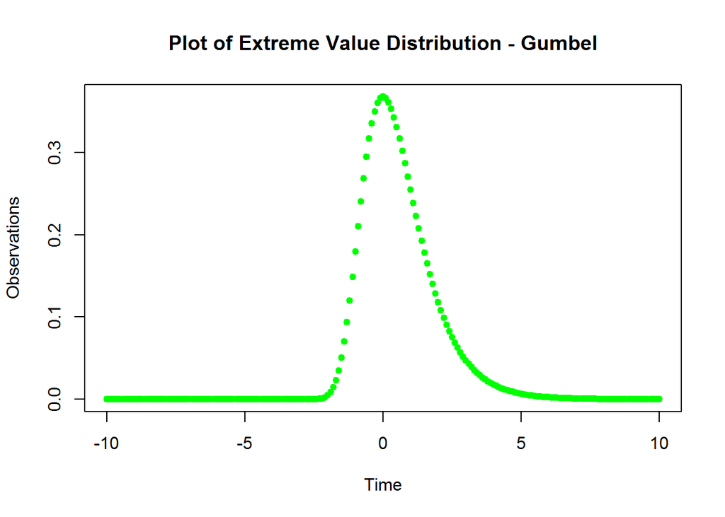

```r
plot(GumbelDistribution, col="green", pch=19, cex=0.8,
     main="Plot of Extreme Value Distribution - Gumbel")
```

## Simulating Frechet Extreme Value Distribution

A Frechet Extreme Value Distribution dataframe is created from the above Frechet density. The beginning six distribution values are displayed, and a plot is drawn of the Frechet Distribution.

```r
FrechetDistribution <- data.frame(x, Frechet_density)
names(FrechetDistribution) <- c("Time", "Observations")
head(FrechetDistribution)
```

```
##    Time Observations
## 1 -10.0            0
## 2  -9.9            0
## 3  -9.8            0
## 4  -9.7            0
## 5  -9.6            0
## 6  -9.5            0
```

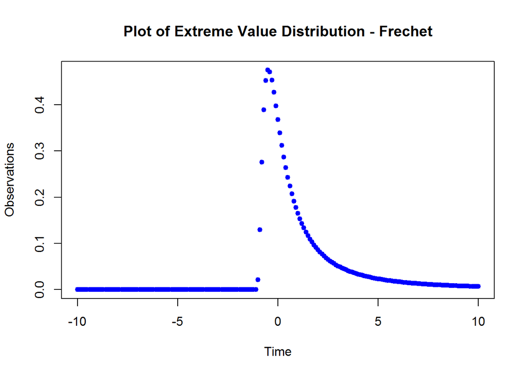

```r
plot(FrechetDistribution, col="blue", pch=19, cex=0.8,
     main="Plot of Extreme Value Distribution - Frechet")
```

## Simulating The Weibull Extreme Value Distribution

A Weibull Extreme Value Distribution dataframe is created from the above Weibull density. The beginning six distribution values are displayed, and a plot is drawn of the Weibull Distribution.

```r
WeibullDistribution <- data.frame(x, Weibull_density)
names(WeibullDistribution) <- c("Time", "Observations")
head(WeibullDistribution)
```

```
##    Time Observations
## 1 -10.0 1.919718e-43
## 2  -9.9 2.338991e-42
## 3  -9.8 2.726787e-41
## 4  -9.7 3.042965e-40
## 5  -9.6 3.252047e-39
## 6  -9.5 3.329823e-38
```

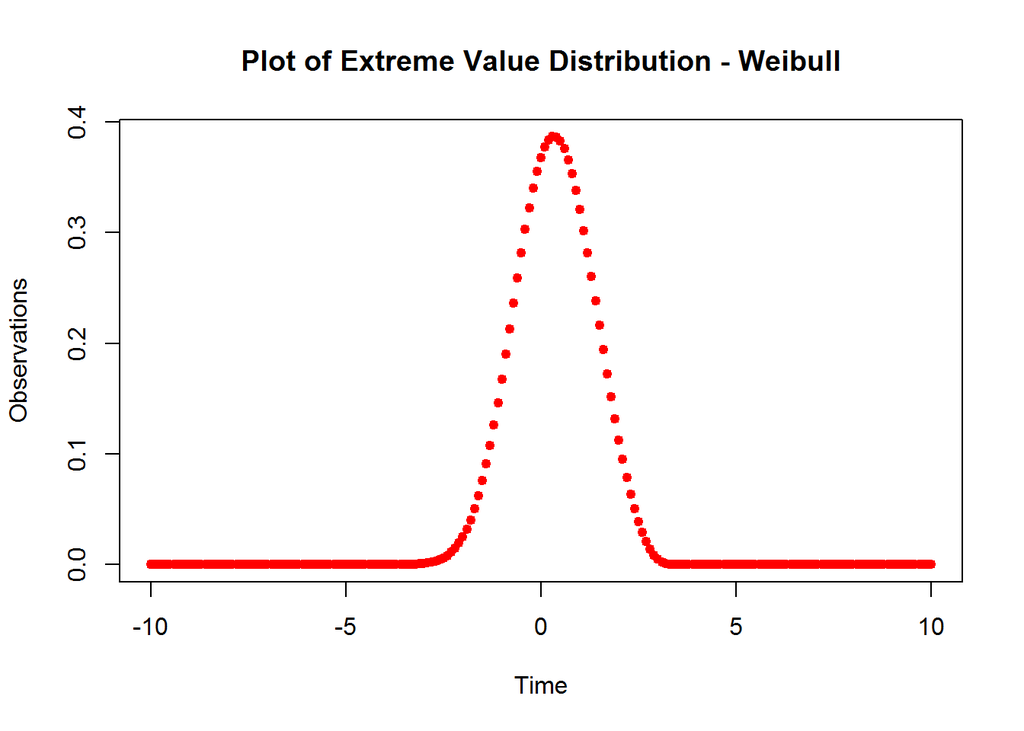

```r
plot(WeibullDistribution, col="red", pch=19, cex=0.8,
     main="Plot of Extreme Value Distribution - Weibull")
```

# Block Maxima Estimation of Extreme Value Distributions

## EVT Block Maxima Estimation of Gumbel Extreme Distribution

Before creating a Block Maxima estimation of the Gumbel Extreme Value data, a histogram of the distribution’s observations is presented, and an Anderson-Darling Test of robustness of the data is made. Then, the Block Maxima estimation is made via fitting the Gumbel data to Block Maxima data, the results are displayed, with a plot of the Gumbel data density. Extreme data is deduced, then plotted. The resulting Extremes are presented in a final Histogram.

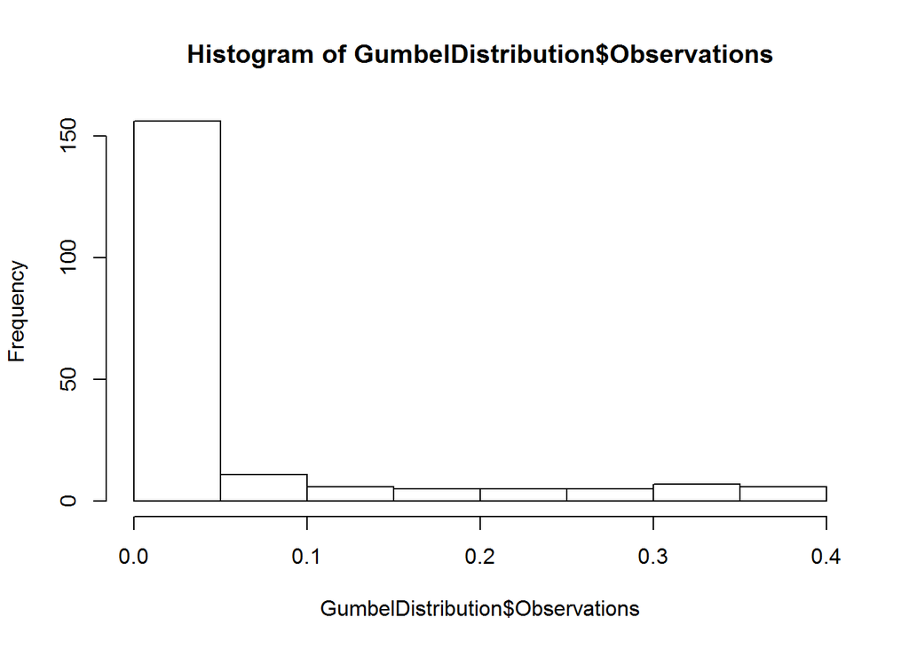

```r
hist(GumbelDistribution$Observations)
```

```r
cat("Anderson - Darling Test of Gumbel Extreme Value Distribution")
```

```
## Anderson - Darling Test of Gumbel Extreme Value Distribution
```

```r
ad.test(GumbelDistribution$Observations)
```

```
##
##  Anderson-Darling normality test
##
## data:  GumbelDistribution$Observations
## A = 39.336, p-value < 2.2e-16
```

```r
cat("Fitting the EV distribution to the block maxima data")
```

```
## Fitting the EV distribution to the block maxima data
```

```r
GumbelGEV <- gev(as.numeric(GumbelDistribution$Observations[1:200]))
fgev(GumbelGEV$data, std.err = FALSE)
```

```
##
## Call: fgev(x = GumbelGEV$data, std.err = FALSE)
## Deviance: -1221.733
##
## Estimates
##       loc      scale      shape
## 0.0004608  0.0014843  1.0017600
##
## Optimization Information
##   Convergence: successful
##   Function Evaluations: 98
##   Gradient Evaluations: 14
```

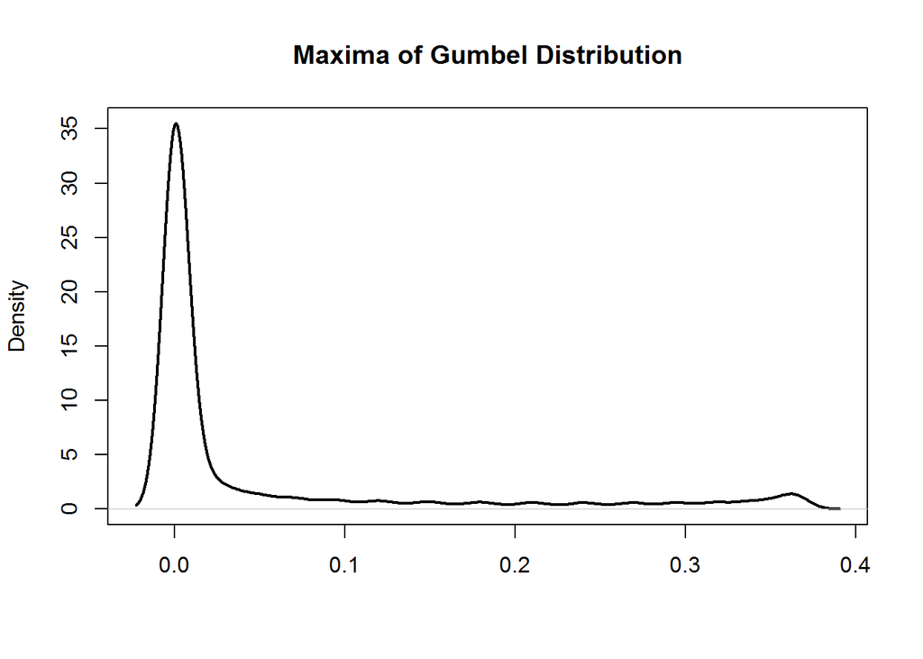

```r
plot(density(GumbelDistribution$Observations), xlab="", main="Maxima of Gumbel Distribution", lwd=2)
```

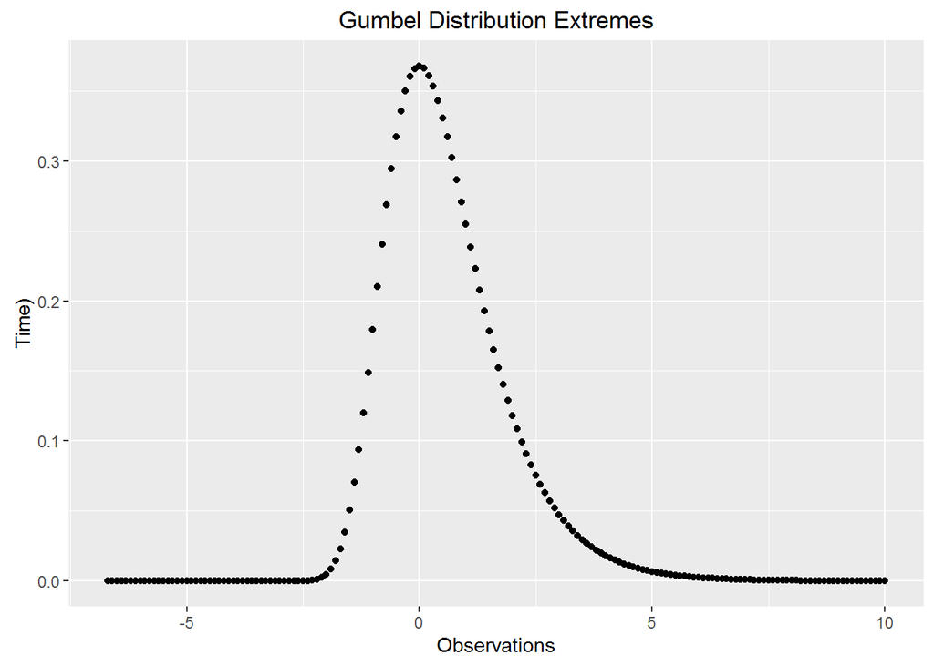

```r
extremes <- GumbelDistribution %>%
  group_by(Observations) %>%
  summarize(max_x=max(Time), min_x=min(Time), n=n())

extremes %>%
  ggplot(aes(x=max_x, y=Observations)) +
  geom_point() +
  xlab('Observations') +
  ylab('Time)') +
  ggtitle("Gumbel Distribution Extremes")
```

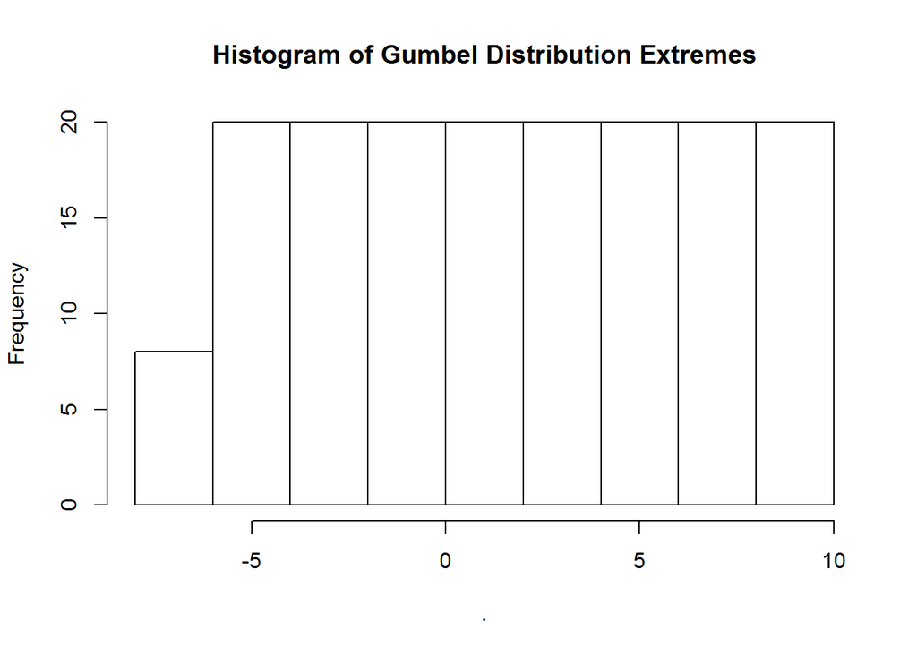

```r
extremes$max_x %>%
  hist(main="Histogram of Gumbel Distribution Extremes")
```

## EVT Block Maxima Estimation of Frechet Extreme Distribution

Before creating a Block Maxima estimation of the Frechet Extreme Value data, a histogram of the distribution’s observations is presented, and an Anderson-Darling Test of robustness of the data is made. Then, the Block Maxima estimation is made via fitting the Frechet data to Block Maxima data, the results are displayed, with a plot of the Frechet data density. Extreme data is deduced, then plotted. The resulting Extremes are presented in a final Histogram.

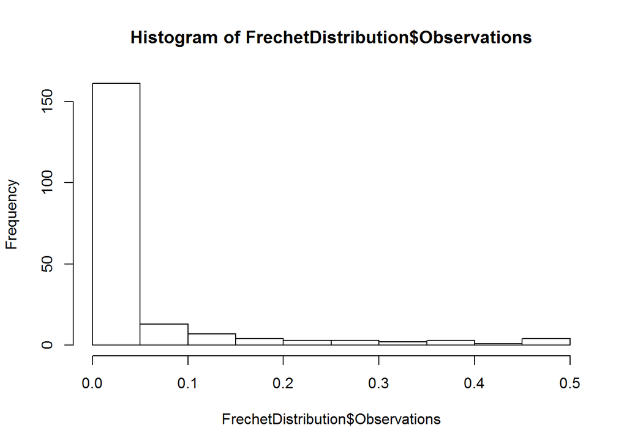

```r
hist(FrechetDistribution$Observations)
```

```r
cat("Anderson - Darling Test of Frechet Extreme Value Distribution")
```

```
## Anderson - Darling Test of Frechet Extreme Value Distribution
```

```r
ad.test(FrechetDistribution$Observations)
```

```
##
##  Anderson-Darling normality test
##
## data:  FrechetDistribution$Observations
## A = 37.254, p-value < 2.2e-16
```

```r
cat("Fitting the EV distribution to the block maxima data")
```

```
## Fitting the EV distribution to the block maxima data
```

```r
FrechetGEV <- gev(as.numeric(FrechetDistribution$Observations[1:200]))
fgev(FrechetGEV$data, std.err = FALSE)
```

```
##
## Call: fgev(x = FrechetGEV$data, std.err = FALSE)
## Deviance: -1082.196
##
## Estimates
##      loc     scale     shape
## 0.002289  0.003840  1.196843
##
## Optimization Information
##   Convergence: successful
##   Function Evaluations: 351
##   Gradient Evaluations: 26
```

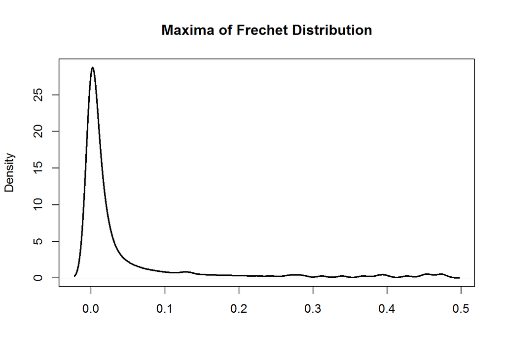

```r
plot(density(FrechetDistribution$Observations), xlab="", main="Maxima of Frechet Distribution", lwd=2)
```

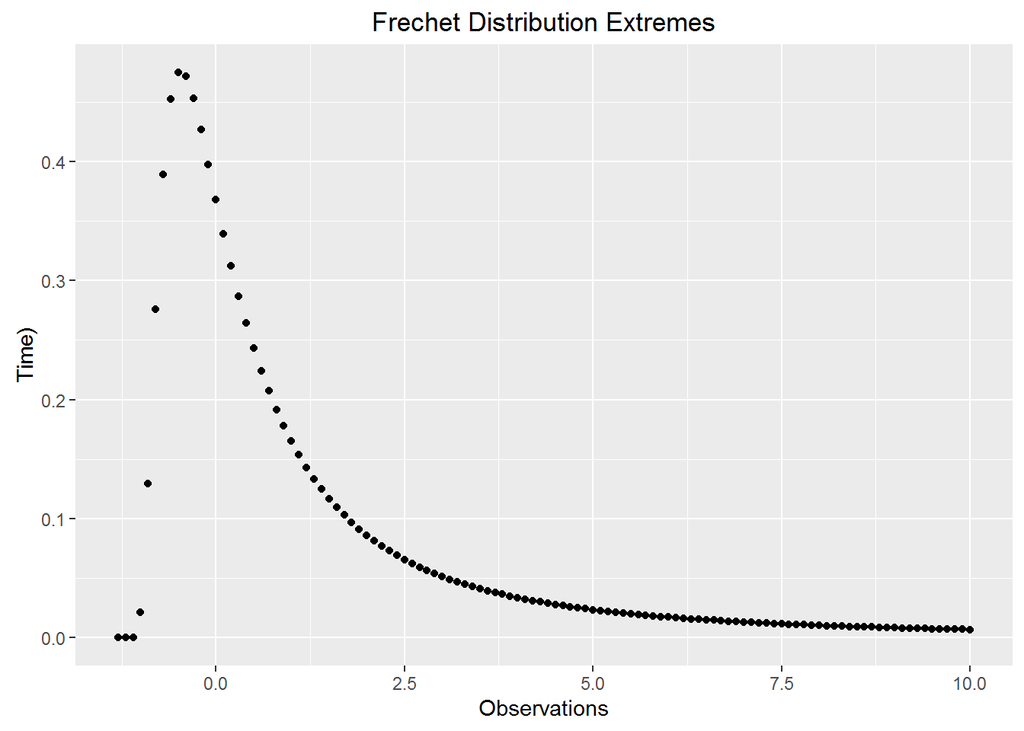

```r
extremes <- FrechetDistribution %>%
  group_by(Observations) %>%
  summarize(max_x=max(Time), min_x=min(Time), n=n())

extremes %>%
  ggplot(aes(x=max_x, y=Observations)) +
  geom_point() +
  xlab('Observations') +
  ylab('Time)') +
  ggtitle("Frechet Distribution Extremes")
```

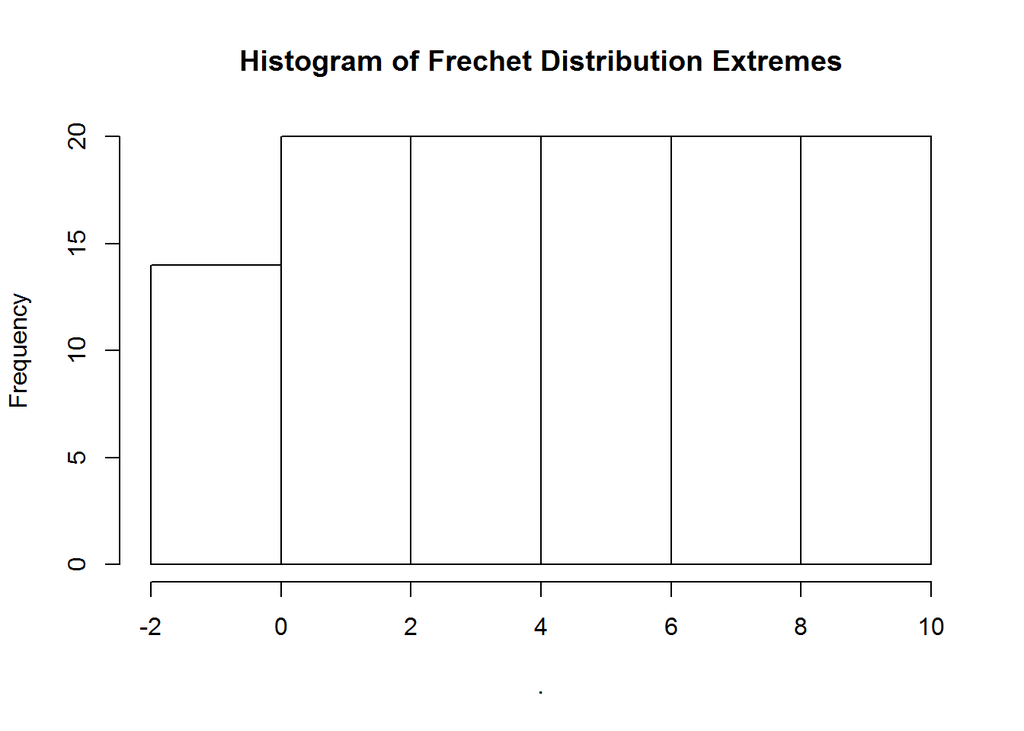

```r
extremes$max_x %>%
  hist(main="Histogram of Frechet Distribution Extremes")
```

## EVT Block Maxima Estimation of Weibull Extreme Distribution

Before creating a Block Maxima estimation of the Weibull Extreme Value data, a histogram of the distribution’s observations is presented, and an Anderson-Darling Test of robustness of the data is made. Then, the Block Maxima estimation is made via fitting the Weibull data to Block Maxima data, the results are displayed, with a plot of the Weibull data density. Extreme data is deduced, then plotted. The resulting Extremes are presented in a final Histogram.

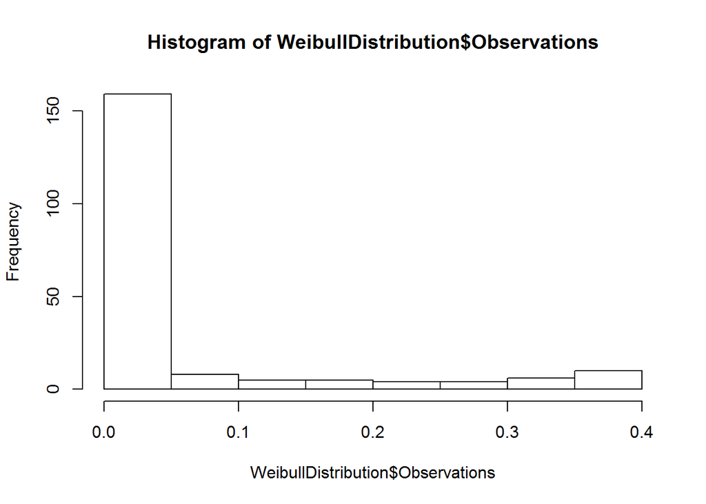

```r
hist(WeibullDistribution$Observations)
```

```r
cat("Anderson - Darling Test of Weibull Extreme Value Distribution")
```

```
## Anderson - Darling Test of Weibull Extreme Value Distribution
```

```r
ad.test(WeibullDistribution$Observations)
```

```
##
##  Anderson-Darling normality test
##
## data:  WeibullDistribution$Observations
## A = 44.371, p-value < 2.2e-16
```

```r
cat("Fitting the EV distribution to the block maxima data")
```

```
## Fitting the EV distribution to the block maxima data
```

```r
WeibullGEV <- gev(as.numeric(WeibullDistribution$Observations[1:200]))
fgev(WeibullGEV$data)
```

```
##
## Call: fgev(x = WeibullGEV$data)
## Deviance: -1754.925
##
## Estimates
##       loc      scale      shape
## 0.0008346  0.0019415  2.0281387
##
## Standard Errors
##       loc      scale      shape
## 1.999e-06  1.999e-06  1.592e-01
##
## Optimization Information
##   Convergence: successful
##   Function Evaluations: 174
##   Gradient Evaluations: 22
```

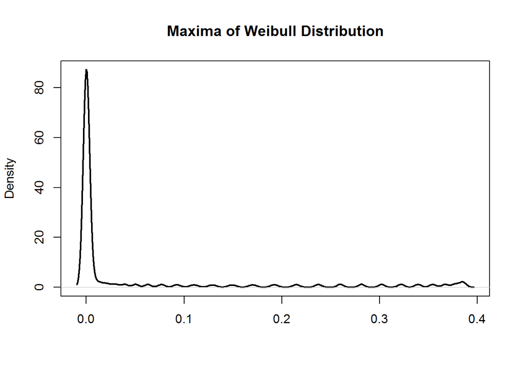

```r
plot(density(WeibullDistribution$Observations), xlab="", main="Maxima of Weibull Distribution", lwd=2)
```

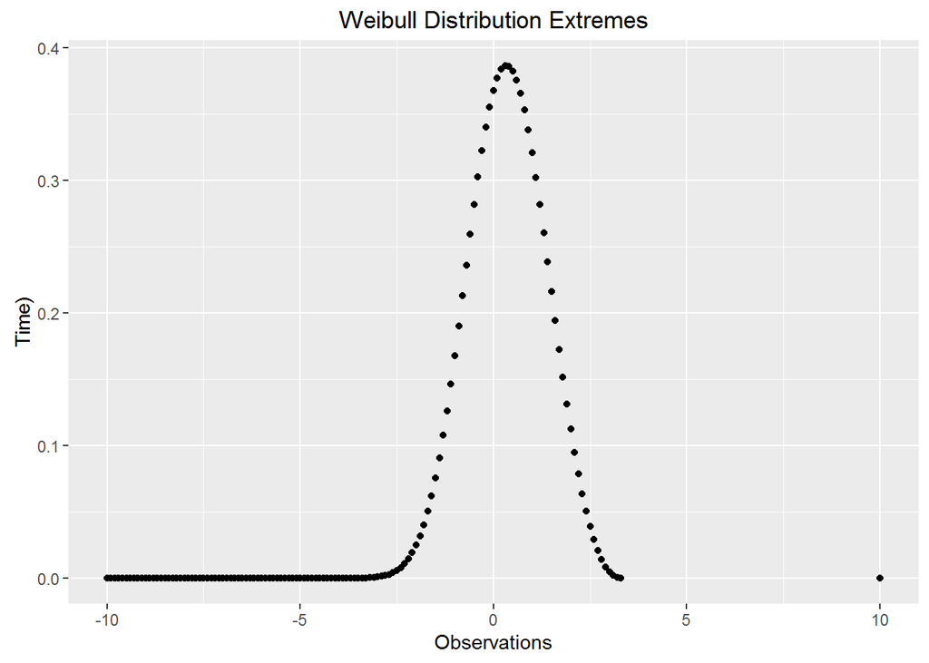

```r
extremes <- WeibullDistribution %>%
  group_by(Observations) %>%
  summarize(max_x=max(Time), min_x=min(Time), n=n())

extremes %>%
  ggplot(aes(x=max_x, y=Observations)) +
  geom_point() +
  xlab('Observations') +
  ylab('Time)') +
  ggtitle("Weibull Distribution Extremes")
```

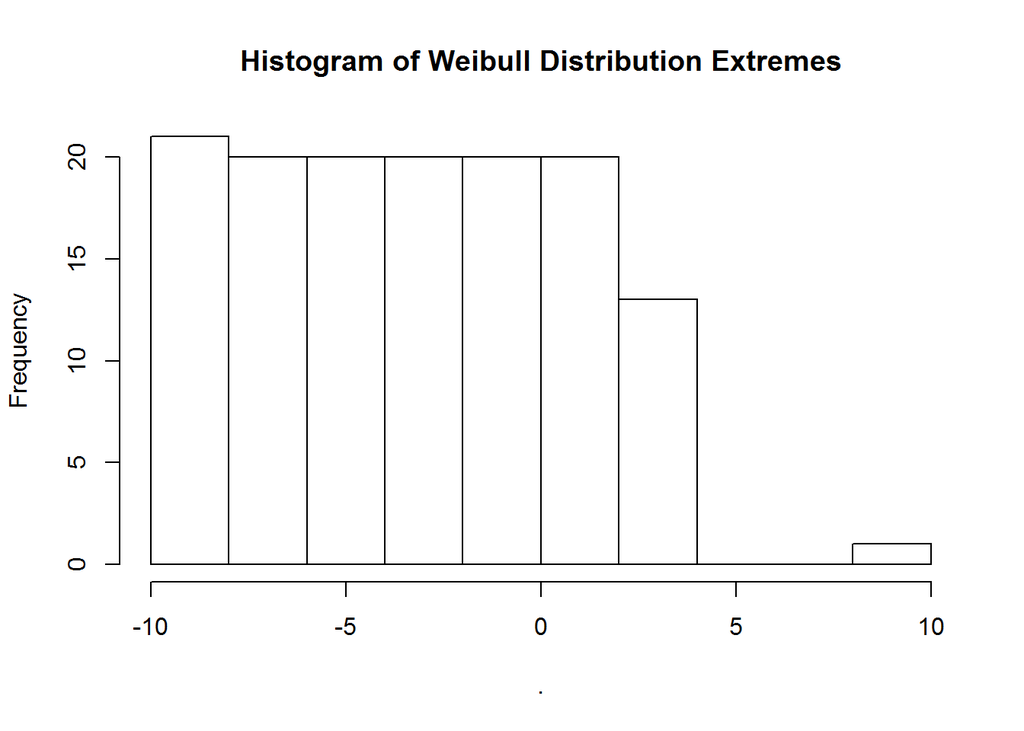

```r
extremes$max_x %>%
  hist(main="Histogram of Weibull Distribution Extremes")
```

# Peaks-Over-Threshold Estimations of Extreme Value Distributions

In the peaks-over-threshold approach in EVT, the initial observations that exceed a certain high threshold are selected. The probability distribution of those selected observations is approximately a generalized Pareto distribution.

## EVT Peaks-Over-Threshold Estimation of Gumbel Extreme Distribution

In order to create a Peaks-Over-Threshold estimation of the Gumbel distribution, a threshold is determined using the POT package in R. Then a maximum likelihood estimation (mle) is created by fitting a Generalized Pareto Distribution. A 95% Confidence Interval is determined from the MLE data. The resulting estimation is then graphically diagnosed via MLE plotting. Finally, predictions based on the data are made using the Generalized Auto-Regressive Conditional Heteroskadacity method.

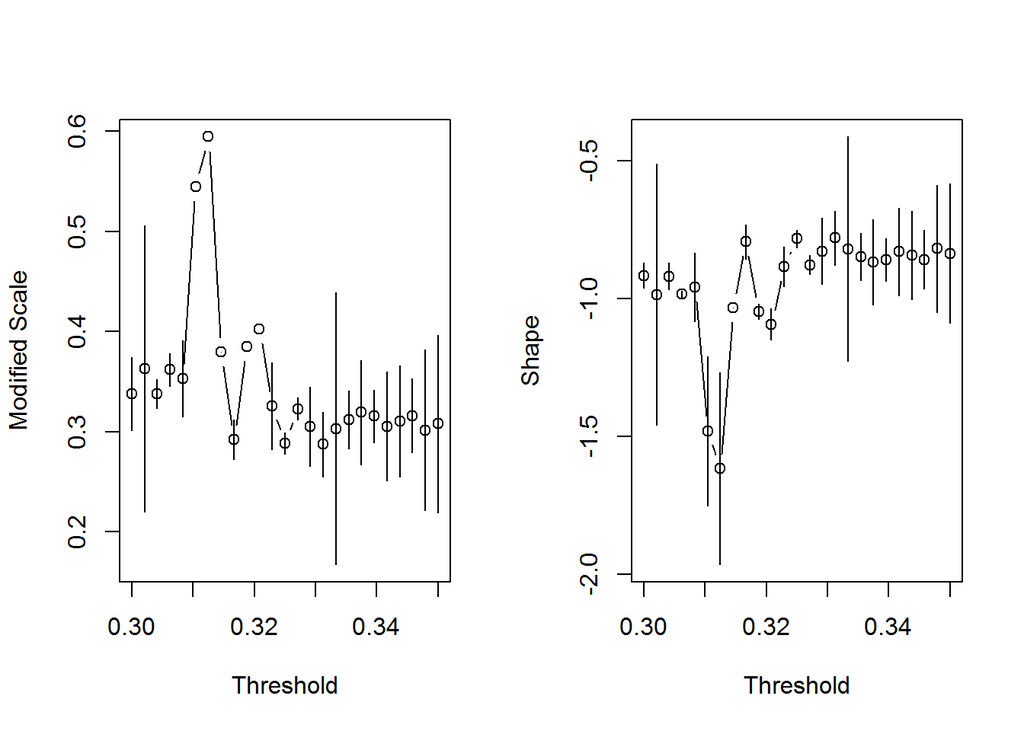

```r
# Determine threshold
par(mfrow=c(1,2))
tcplot(GumbelDistribution$Observations, u.range = c(0.3, 0.35))
```

```r
# Fit the Generalizaed Pareto Distribution
mle <- fitgpd(GumbelDistribution$Observations, thresh = .35, shape = 0, est = "mle")

# Confidence Intervals
gpd.fiscale(mle, conf = 0.95)
```

```
## conf.inf.scale conf.sup.scale
##    0.002667761    0.022090121
```

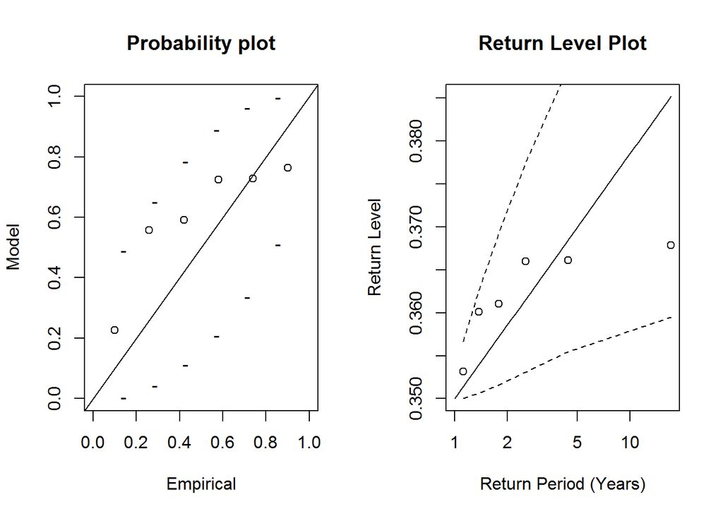

```r
# graphic diagnostics for the fitted model
par(mfrow=c(1,2))
plot(mle, npy = 1, which=1)
plot(mle, npy = 1, which=4)
```

```r
# Fit models with Generalized Auto-Regressive Conditional Heteroskadacity
gumbel.fitted.model <- garchFit(formula=~ arma(1, 0) + garch(1, 1),
                                 data=GumbelDistribution$Observations,
                                 cond.dist="norm", trace=FALSE)

# Produce forecasts
model.forecast <- fGarch::predict(object=gumbel.fitted.model, n.ahead=1)

cat("Forecasts for Gumbel Distribution observations")
```

```
## Forecasts for Gumbel Distribution observations
```

```r
model.forecast
```

```
##   meanForecast    meanError standardDeviation
## 1 3.453016e-05 0.0001002756      0.0001002756
```

## EVT Peaks-Over-Threshold Estimation of Frechet Extreme Distribution

A Peaks-Over-Threshold estimation of the Frechet distribution, is determined via creation of a maximum likelihood estimation (mle) by fitting a Generalized Pareto Distribution. A 95% Confidence Interval is determined from the MLE data. The resulting estimation is then graphically diagnosed via MLE plotting. Finally, predictions based on the data are made using the Generalized Auto-Regressive Conditional Heteroskadacity method.

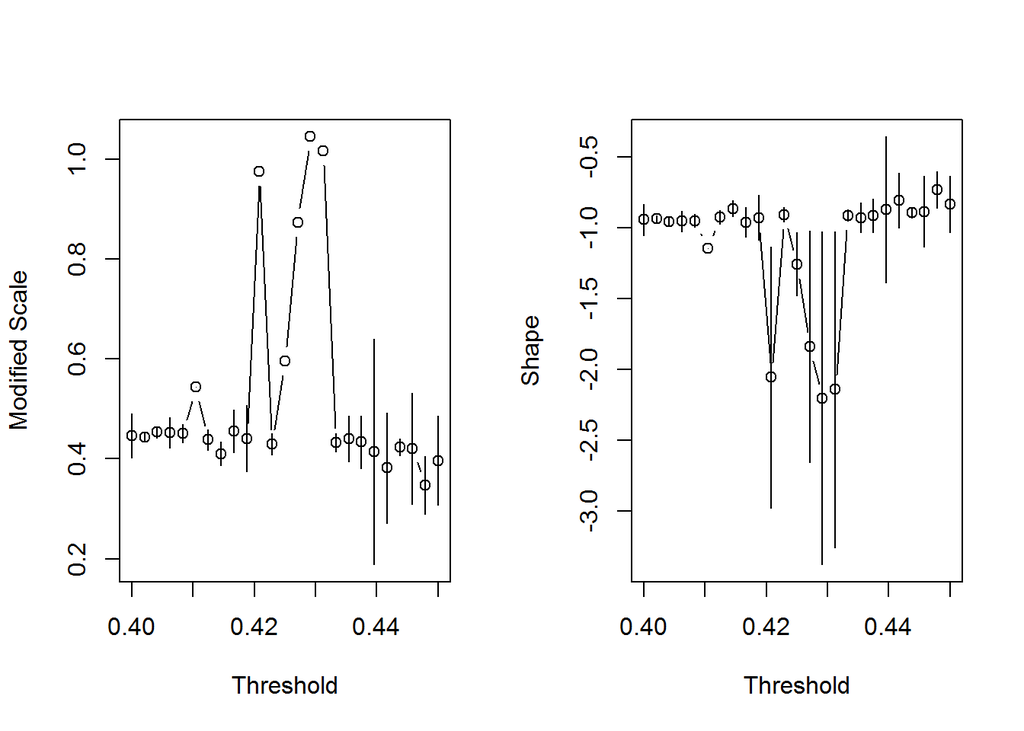

```r
# Determine threshold
par(mfrow=c(1,2))
tcplot(FrechetDistribution$Observations, u.range = c(0.4, 0.45))
```

```r
# Fit the Generalizaed Pareto Distribution
mle <- fitgpd(FrechetDistribution$Observations, thresh = .35, shape = 0, est = "mle")

# Confidence Intervals
gpd.fiscale(mle, conf = 0.95)
```

```
## conf.inf.scale conf.sup.scale
##     0.02435046     0.13408869
```

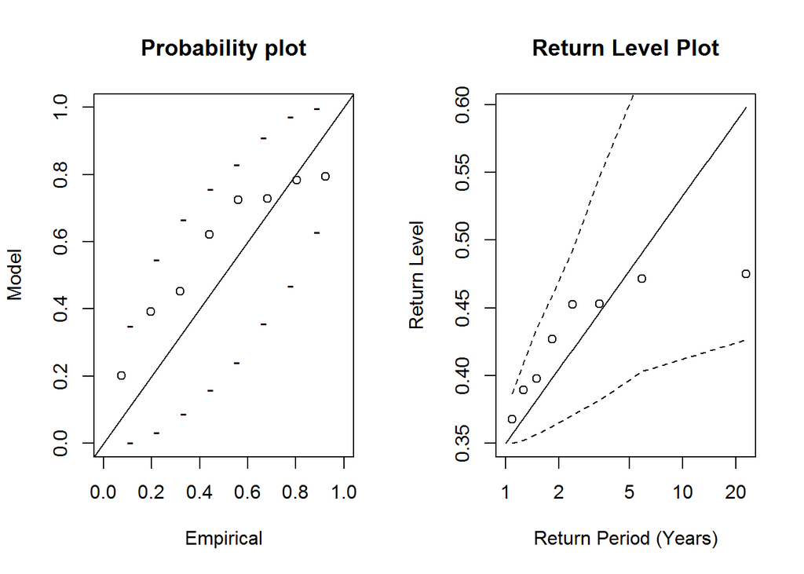

```r
# graphic diagnostics for the fitted model
par(mfrow=c(1,2))
plot(mle, npy = 1, which=1)
plot(mle, npy = 1, which=4)
```

```r
# Fit models with Generalized Auto-Regressive Conditional Heteroskadacity
frechet.fitted.model <- garchFit(formula=~ arma(1, 0) + garch(1, 1),
                                 data=FrechetDistribution$Observations,
                                 cond.dist="norm", trace=FALSE)

model.forecast <- fGarch::predict(object=frechet.fitted.model, n.ahead=1)

cat("Forecasts for Frechet Distribution observations")
```

```
## Forecasts for Frechet Distribution observations
```

```r
model.forecast
```

```
##   meanForecast  meanError standardDeviation
## 1  0.007469903 0.00117062        0.00117062
```

## EVT Peaks-Over-Threshold Estimation of Weibull Extreme Distribution

In order to create a Peaks-Over-Threshold estimation of the Weibull distribution, a threshold is determined using the POT package in R. Then a maximum likelihood estimation (mle) is created by fitting a Generalized Pareto Distribution. A 95% Confidence Interval is determined from the MLE data. The resulting estimation is then graphically diagnosed via MLE plotting. Finally, predictions based on the data are made using the Generalized Auto-Regressive Conditional Heteroskadacity method.

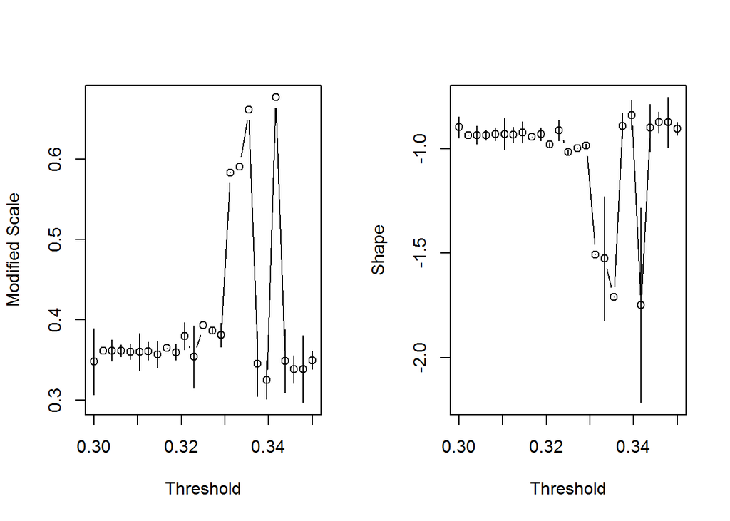

```r
# Determine threshold
par(mfrow=c(1,2))
tcplot(WeibullDistribution$Observations, u.range = c(0.3, 0.35))
```

```r
# Fit the Generalizaed Pareto Distribution
mle <- fitgpd(WeibullDistribution$Observations, thresh = .35, shape = 0, est = "mle")

# Confidence Intervals
gpd.fiscale(mle, conf = 0.95)
```

```
## conf.inf.scale conf.sup.scale
##    0.008982837    0.037852127
```

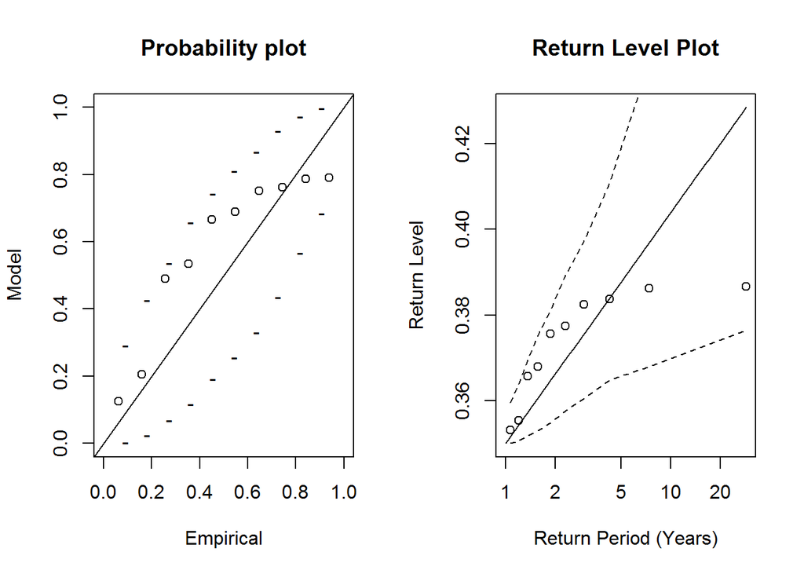

```r
# graphic diagnostics for the fitted model
par(mfrow=c(1,2))
plot(mle, npy = 1, which=1)
plot(mle, npy = 1, which=4)
```

```r
# Fit models with Generalized Auto-Regressive Conditional Heteroskadacity
weibull.fitted.model <- garchFit(formula=~ arma(1, 0) + garch(1, 1),
                                 data=WeibullDistribution$Observations,
                                 cond.dist="norm", trace=FALSE)

# Produce forecasts
model.forecast <- fGarch::predict(object=weibull.fitted.model, n.ahead=1)

cat("Forecasts for Weibull Distribution observations")
```

```
## Forecasts for Weibull Distribution observations
```

```r
model.forecast
```

```
##   meanForecast    meanError standardDeviation
## 1 1.795185e-06 0.0001072333      0.0001072333
```